# Diamond Price Data Set

## Introduction to the Diamond Price Dataset Analysis

Diamonds are one of the most valuable gemstones in the world, with prices influenced by multiple factors such as carat, /n cut, color, clarity, and depth. Understanding the pricing structure of diamonds is essential for buyers, sellers, and businesses in the jewelry industry.

In this project, I analyze the Diamond Price Dataset from Kaggle, which contains detailed information about over 53,000 diamonds,/n including their physical attributes and corresponding market prices. The objective is to explore patterns in diamond pricing, identify key factors affecting value, and build predictive models to estimate diamond prices accurately.

Dataset Overview The dataset consists of 53,940 observations with the following key features:

Carat – The weight of the diamond (primary factor affecting price).  
Cut – The quality of the diamond's cut (Fair, Good, Very Good, Premium, Ideal).  
Color – Diamond color, graded from J (worst) to D (best).  
Clarity – Measurement of inclusions/flaws (I1, SI2, SI1, ..., IF).  
Depth & Table – Proportions affecting brilliance.  
Price – The target variable (price in US dollars).  
Why This Project Matters?  
This project provides valuable insights into the pricing structure of diamonds, helping jewelers, investors, and customers make data-driven decisions. By building an accurate pricing model, we can predict the value of diamonds based on their characteristics, leading to better transparency in the diamond market.

## importing data and packages

```python
#importing packages
import numpy as np
import pandas as pd
import matplotlib.pyplot as plt
import seaborn as sns
sns.set
import warnings
warnings.filterwarnings("ignore")
```

```python
df= pd.read_csv("C:/Users/Ma'mun/Desktop/New folder/type of the Diamond new.csv")
```

## EDA and preprocessing

```python
df.head()
```

|  | cut | color | clarity | carat | depth | table | price | x (Premium) | z (Very Good) | y (Good) |
| --- | --- | --- | --- | --- | --- | --- | --- | --- | --- | --- |
| 0 | Fair | E | VS2 | 0.22 | 65.1 | 61.0 | 337 | 3.87 | 2.49 | 3.78 |
| 1 | Fair | E | SI2 | 0.86 | 55.1 | 69.0 | 2757 | 6.45 | 3.52 | 6.33 |
| 2 | Fair | F | SI2 | 0.96 | 66.3 | 62.0 | 2759 | 6.27 | 4.07 | 5.95 |
| 3 | Fair | F | VS2 | 0.70 | 64.5 | 57.0 | 2762 | 5.57 | 3.58 | 5.53 |
| 4 | Fair | F | VS2 | 0.70 | 65.3 | 55.0 | 2762 | 5.63 | 3.66 | 5.58 |

```python
df.info()
```

```
<class 'pandas.core.frame.DataFrame'>
RangeIndex: 53940 entries, 0 to 53939
Data columns (total 10 columns):
 #   Column         Non-Null Count  Dtype
---  ------         --------------  -----
 0   cut            53940 non-null  object
 1   color          53940 non-null  object
 2   clarity        53940 non-null  object
 3   carat          53940 non-null  float64
 4   depth          53940 non-null  float64
 5   table          53940 non-null  float64
 6   price          53940 non-null  int64
 7   x (Premium)    53940 non-null  float64
 8   z (Very Good)  53940 non-null  float64
 9   y (Good)       53940 non-null  float64
dtypes: float64(6), int64(1), object(3)
memory usage: 4.1+ MB
```

```python
df.describe()
```

|  | carat | depth | table | price | x (Premium) | z (Very Good) | y (Good) |
| --- | --- | --- | --- | --- | --- | --- | --- |
| count | 53940.000000 | 53940.000000 | 53940.000000 | 53940.000000 | 53940.000000 | 53940.000000 | 53940.000000 |
| mean | 0.797940 | 61.749405 | 57.457184 | 3932.799722 | 5.731157 | 3.538734 | 5.734526 |
| std | 0.474011 | 1.432621 | 2.234491 | 3989.439738 | 1.121761 | 0.705699 | 1.142135 |
| min | 0.200000 | 43.000000 | 43.000000 | 326.000000 | 0.000000 | 0.000000 | 0.000000 |
| 25% | 0.400000 | 61.000000 | 56.000000 | 950.000000 | 4.710000 | 2.910000 | 4.720000 |
| 50% | 0.700000 | 61.800000 | 57.000000 | 2401.000000 | 5.700000 | 3.530000 | 5.710000 |
| 75% | 1.040000 | 62.500000 | 59.000000 | 5324.250000 | 6.540000 | 4.040000 | 6.540000 |
| max | 5.010000 | 79.000000 | 95.000000 | 18823.000000 | 10.740000 | 31.800000 | 58.900000 |

```python
s = (df.dtypes =="object")
object_cols = list(s[s].index)
print("Categorical variables:")
print(object_cols)
```

```
Categorical variables:
['cut', 'color', 'clarity']
```

```python
from sklearn.preprocessing import OneHotEncoder, LabelEncoder
label_df = df.copy()

# Apply label encoder to each column with categorical data
label_encoder = LabelEncoder()
for col in object_cols:
    label_df[col] = label_encoder.fit_transform(label_df[col])
label_df.head()
```

|  | cut | color | clarity | carat | depth | table | price | x (Premium) | z (Very Good) | y (Good) |
| --- | --- | --- | --- | --- | --- | --- | --- | --- | --- | --- |
| 0 | 0 | 1 | 5 | 0.22 | 65.1 | 61.0 | 337 | 3.87 | 2.49 | 3.78 |
| 1 | 0 | 1 | 3 | 0.86 | 55.1 | 69.0 | 2757 | 6.45 | 3.52 | 6.33 |
| 2 | 0 | 2 | 3 | 0.96 | 66.3 | 62.0 | 2759 | 6.27 | 4.07 | 5.95 |
| 3 | 0 | 2 | 5 | 0.70 | 64.5 | 57.0 | 2762 | 5.57 | 3.58 | 5.53 |
| 4 | 0 | 2 | 5 | 0.70 | 65.3 | 55.0 | 2762 | 5.63 | 3.66 | 5.58 |

```python
correlation = df[['price','x (Premium)','z (Very Good)','y (Good)','carat']].corr()
correlation
```

|  | price | x (Premium) | z (Very Good) | y (Good) | carat |
| --- | --- | --- | --- | --- | --- |
| price | 1.000000 | 0.884435 | 0.861249 | 0.865421 | 0.921591 |
| x (Premium) | 0.884435 | 1.000000 | 0.970772 | 0.974701 | 0.975094 |
| z (Very Good) | 0.861249 | 0.970772 | 1.000000 | 0.952006 | 0.953387 |
| y (Good) | 0.865421 | 0.974701 | 0.952006 | 1.000000 | 0.951722 |
| carat | 0.921591 | 0.975094 | 0.953387 | 0.951722 | 1.000000 |

## Data Visualizations

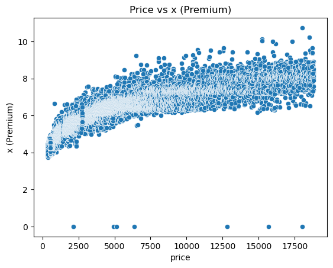

```python
sns.scatterplot(x='price',y='x (Premium)',data=df)
plt.title('Price vs x (Premium)')
```

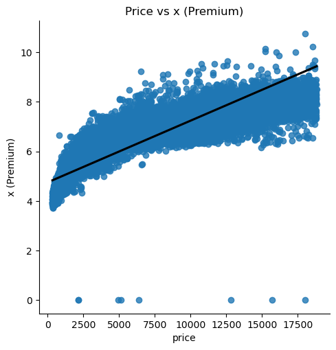

```python
sns.lmplot(x='price',y='x (Premium)',data=df,line_kws={"color": "black"})
plt.title('Price vs x (Premium)')
```

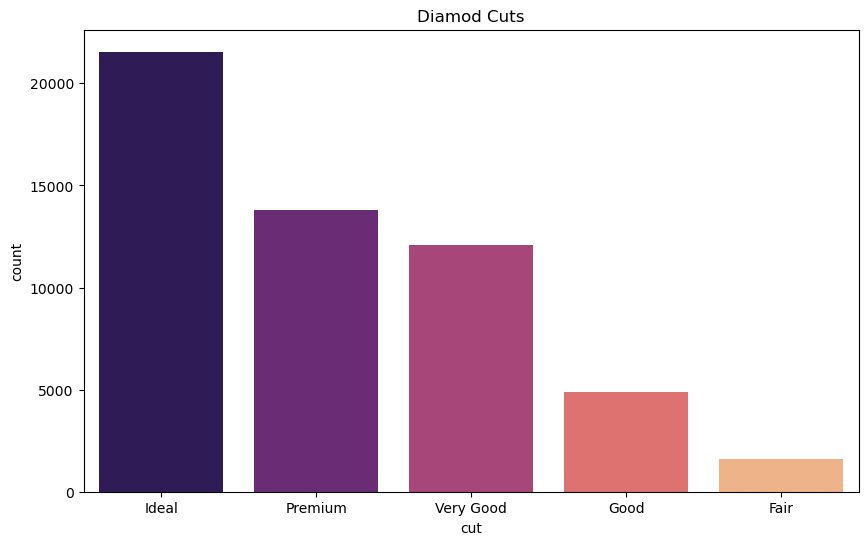

```python
plt.figure(figsize=(10, 6))
order= df['cut'].value_counts().index
sns.countplot(x='cut',data=df,palette='magma',order=order)
plt.title('Diamod Cuts')
```

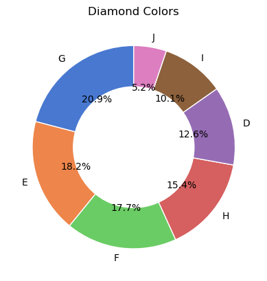

```python
types = df.value_counts('color')
plt.pie(types, labels=types.index, autopct='%1.1f%%',colors = sns.color_palette("muted"),  startangle=90,wedgeprops={'edgecolor': 'white'})

center_circle = plt.Circle((0,0), 0.6, fc='white')
plt.gca().add_artist(center_circle)
plt.title('Diamond Colors')
```

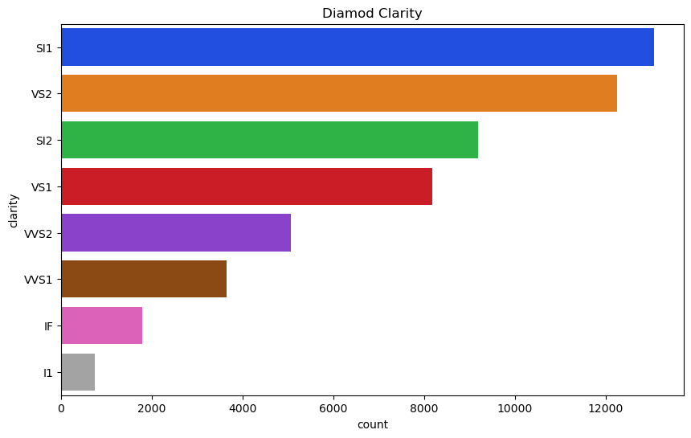

```python
plt.figure(figsize=(10, 6))
order= df['clarity'].value_counts().index
sns.countplot(y='clarity',data=df,palette='bright',order=order)
plt.title('Diamod Clarity')
```

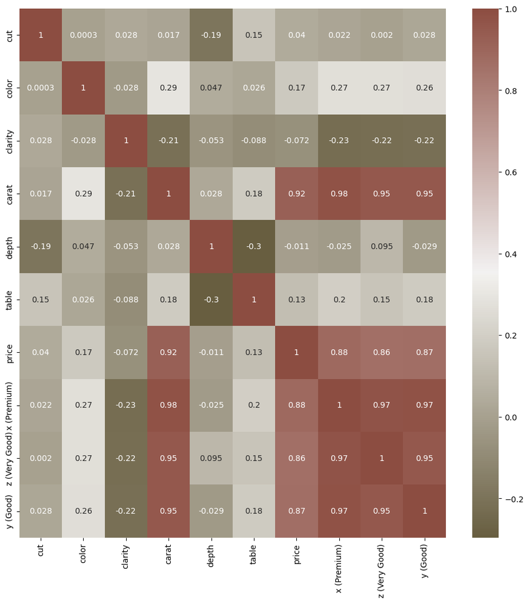

```python
cmap = sns.diverging_palette(70,20,s=50, l=40, n=6,as_cmap=True)
corrmat= label_df.corr()
f, ax = plt.subplots(figsize=(12,12))
sns.heatmap(corrmat,cmap=cmap,annot=True, )
```

## Machine Learning

```python
import xgboost as xgb
from xgboost import XGBRegressor
from sklearn.model_selection import train_test_split
from sklearn.metrics import r2_score, mean_squared_error

x=label_df.drop(["price"],axis =1)
y=label_df["price"]

x_train,x_test,y_train,y_test = train_test_split(x,y,test_size=0.3,random_state=24)
```

```python
model = XGBRegressor()
model.fit(x_train, y_train)
```

```
XGBRegressor(base_score=None, booster=None, callbacks=None,
             colsample_bylevel=None, colsample_bynode=None,
             colsample_bytree=None, device=None, early_stopping_rounds=None,
             enable_categorical=False, eval_metric=None, feature_types=None,
             gamma=None, grow_policy=None, importance_type=None,
             interaction_constraints=None, learning_rate=None, max_bin=None,
             max_cat_threshold=None, max_cat_to_onehot=None,
             max_delta_step=None, max_depth=None, max_leaves=None,
             min_child_weight=None, missing=nan, monotone_constraints=None,
             multi_strategy=None, n_estimators=None, n_jobs=None,
             num_parallel_tree=None, random_state=None, ...)
```

```python
y_pred = model.predict(x_test)
print(f"R-squared: {r2_score(y_test, y_pred) *100:.2f}%")
print(f"MSE: {mean_squared_error(y_test, y_pred):.2f}")
```

```
R-squared: 98.03%
MSE: 318132.14
```

#### This model model shows accuracy shows 98% thats an awesome model to predict this data